# Weather and Climate Related Analysis of the New York City Area

#### Pearson Correlaion

The Pearson correlation coefficient is a measure of the strength and direction of linear association between two continuous variables. It quantifies how closely the variables co-vary around their respective means, taking values in the range −1 to +1, where +1 indicates perfect positive linear dependence, −1 indicates perfect negative linear dependence, and 0 indicates no linear relationship.

Mathematically, Pearson correlation is the standardized covariance, defined as the covariance of two variables divided by the product of their standard deviations. This standardization makes the measure unit-free and directly comparable across different variable pairs. A key property is its symmetry: the correlation between $X$ and $Y$ is identical to that between $Y$ and $X$.

Pearson correlation is most appropriate when the relationship between variables is approximately linear, the data are continuous, and extreme outliers are limited, as outliers can exert a disproportionate influence on the coefficient. While a strong Pearson correlation suggests meaningful co-movement, it does not imply causality and may fail to capture nonlinear or regime-dependent relationships.

In applied analysis, Pearson correlation is widely used for exploratory data analysis, feature screening, and multicollinearity diagnostics. In meteorological and climatological contexts, it helps identify coupled processes—such as relationships between radiation, temperature, humidity, and wind—while serving as a first-pass diagnostic before more advanced dependence modeling.

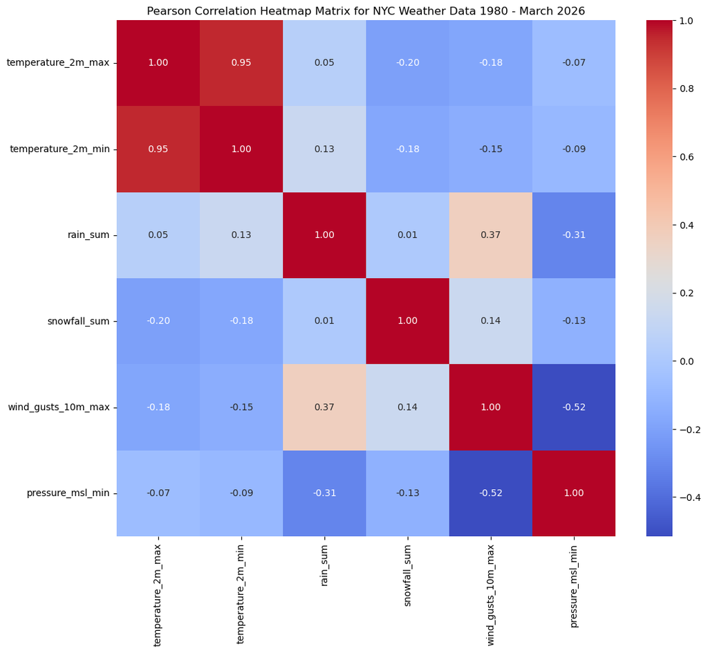

```python
import matplotlib.pyplot as plt
import seaborn as sns

# Calculate the Pearson correlation matrix, excluding the non-numeric 'date' column
correlation_matrix = no_date_cols.corr(method='pearson')

# Create a heatmap
plt.figure(figsize=(12, 10))
sns.heatmap(correlation_matrix, annot=True, cmap='coolwarm', fmt=".2f")
plt.title('Pearson Correlation Heatmap Matrix for NYC Weather Data 1980 - March 2026')
plt.show()
```

For Pearson correlation applied prior, the above Pearson correlation heatmap conveys much about association among the variables, and level of linearity. Pearson correlation is a faster alternative to pair plots (scatter plots). Namely, the display can be generated faster. However, values alone may not allow one an easy vision of the level of linearity or association. Say, discerning between 0.6 to 0.7.

**NOTE:** naturally, data pairs don't need to have a linear relationship in general.

#### Scatter Plots

Scatter plots are a primary graphical tool for examining the relationship between two quantitative variables. By plotting paired observations in two-dimensional space, scatter plots reveal the direction, strength, and form of association between variables, providing immediate insight into whether relationships are linear, nonlinear, or absent.

Beyond correlation, scatter plots are especially valuable for diagnosing structural features in data, such as clusters, regimes, heteroskedasticity, and outliers. Patterns like curvature, fan-shaped dispersion, or distinct groupings often indicate that simple linear models may be inadequate and that transformations, stratification, or nonlinear approaches are warranted.

In applied analysis, scatter plots serve as a critical complement to numerical measures such as Pearson correlation. While correlation summarizes linear co-movement with a single statistic, scatter plots expose context and complexity that summary measures can obscure. In fields such as meteorology and climatology, scatter plots help identify coupled processes (e.g., radiation–temperature or wind–pressure relationships), regime dependence, and physically meaningful constraints, making them an essential diagnostic step prior to formal modeling.

**AGAIN**: naturally, data pairs don't need to have a linear relationship in general.

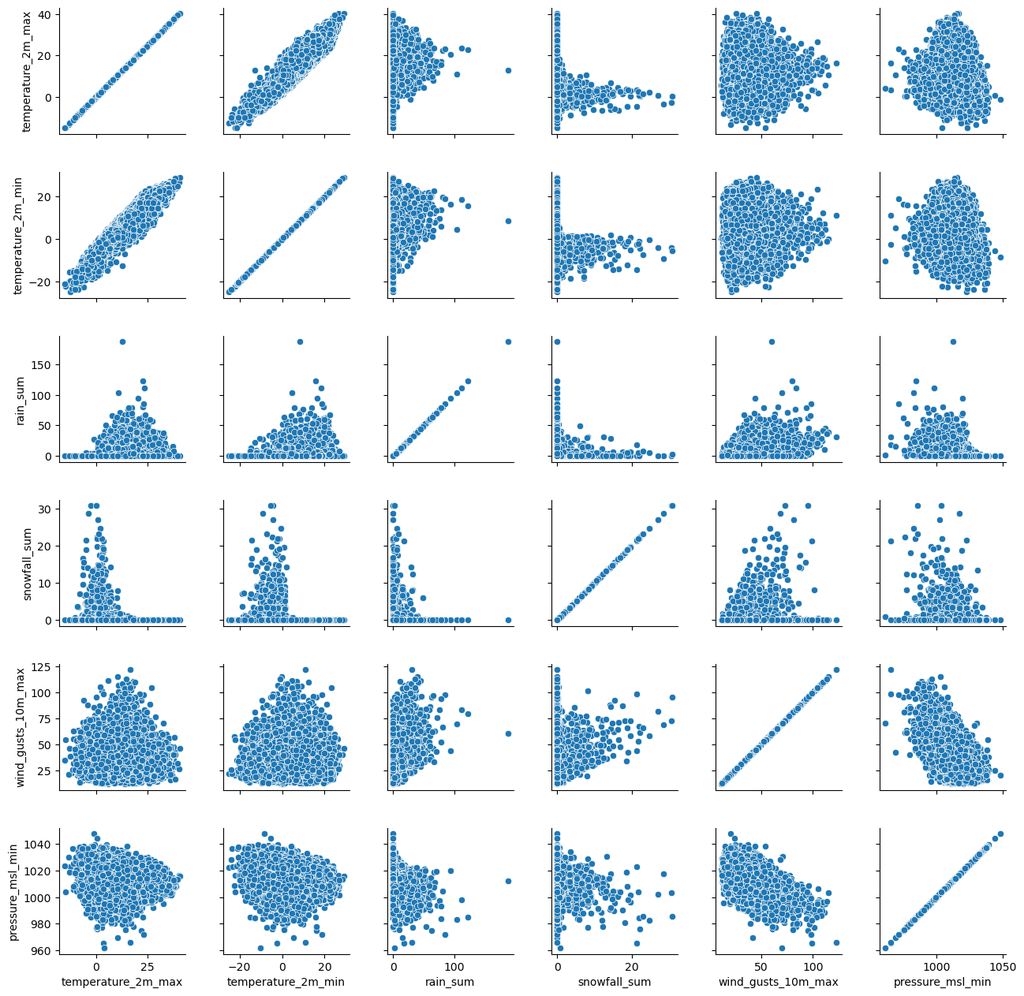

```python
# Creating PairGrid with three columns
g = sns.PairGrid(no_date_cols)
# Mapping scatterplots
g.map(sns.scatterplot)

# Adjusting columns specification
plt.subplots_adjust(left = 0.1, right = 0.9, top = 0.9, bottom = 0.1, wspace = 0.3, hspace = 0.3)

# Showing plot
plt.show()
```

#### Histograms and Quantile–Quantile (Q–Q) Graphs

Histograms are a fundamental graphical tool for visualizing the empirical distribution of a variable. By grouping observations into bins, histograms reveal key features such as central tendency, spread, skewness, multimodality, and the presence of outliers. They provide an intuitive, nonparametric view of data structure and are especially useful for identifying departures from symmetry, heavy tails, or regime mixtures that may not be evident from summary statistics alone. The choice of bin width influences interpretation, making histograms most effective as an exploratory diagnostic rather than a precise inferential tool.

Quantile–Quantile (Q–Q) graphs compare the quantiles of an observed dataset to the quantiles of a reference distribution, most commonly the normal distribution. If the data follow the reference distribution, the points align approximately along a straight line. Systematic deviations from linearity indicate distributional differences, such as skewness (curvature), heavy or light tails (divergence at the extremes), or outliers (isolated departures). Q–Q plots are particularly powerful for diagnosing non-normality and tail behavior, which are critical considerations in statistical modeling and hypothesis testing.

Together, histograms and Q–Q graphs complement numerical descriptive statistics by providing visual diagnostics of distributional form. Histograms offer a broad, intuitive overview of data shape, while Q–Q graphs provide a precise assessment of how empirical distributions differ from theoretical expectations. Used jointly, they guide appropriate choices of transformations, distributional assumptions, and modeling strategies in applied analysis.

**Histograms + Kernel Density:**

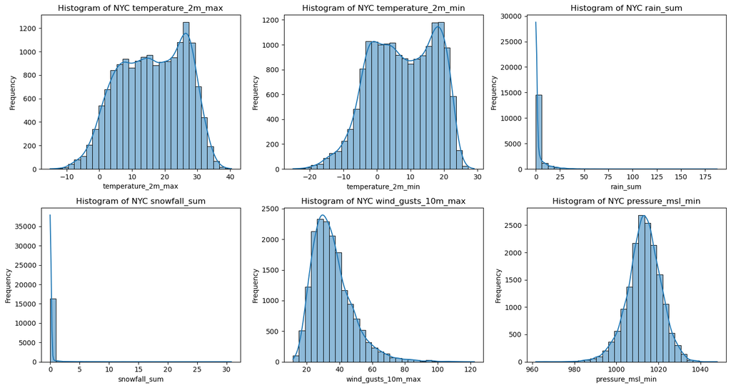

```python
# Get numerical columns, excluding 'date'
numeric_cols = daily_dataframe.drop(columns=['date']).columns

# Determine grid size for subplots
n_cols = 3  # Number of columns in the subplot grid
n_rows = (len(numeric_cols) + n_cols - 1) // n_cols # Calculate rows needed

plt.figure(figsize=(n_cols * 5, n_rows * 4))

for i, col in enumerate(numeric_cols):
    plt.subplot(n_rows, n_cols, i + 1)
    sns.histplot(daily_dataframe[col], kde=True, bins=30)
    plt.title(f'Histogram of NYC {col}')
    plt.xlabel(col)
    plt.ylabel('Frequency')

plt.tight_layout()
plt.show()
```

**Quantile-Quantile Plots:**

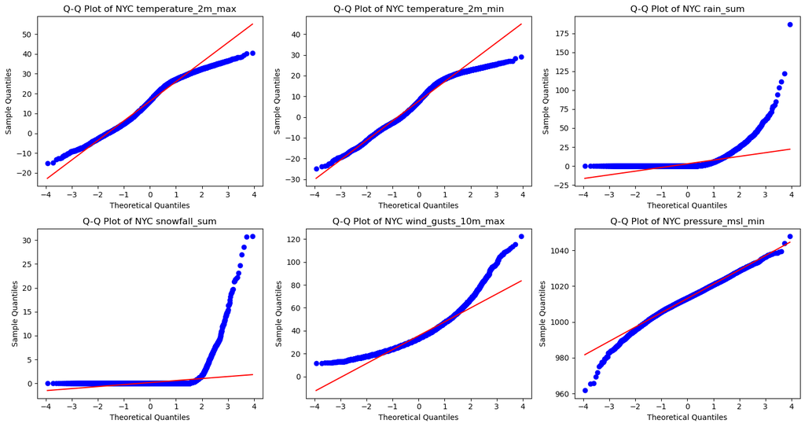

```python
import scipy.stats as stats

# Get numerical columns, excluding 'date'
numeric_cols = daily_dataframe.drop(columns=['date']).columns

# Determine grid size for subplots
n_cols = 3  # Number of columns in the subplot grid
n_rows = (len(numeric_cols) + n_cols - 1) // n_cols # Calculate rows needed

plt.figure(figsize=(n_cols * 5, n_rows * 4))

for i, col in enumerate(numeric_cols):
    plt.subplot(n_rows, n_cols, i + 1)
    stats.probplot(daily_dataframe[col], dist="norm", plot=plt)
    plt.title(f'Q-Q Plot of NYC {col}')
    plt.xlabel('Theoretical Quantiles')
    plt.ylabel('Sample Quantiles')

plt.tight_layout()
plt.show()
```

## A Basic Introduction for Extreme Value Analysis (General Case)

**Extreme Value analysis (EVA) or Extreme Value Theory (EVT)** is essential in climate science to study rare and extreme climate events, such as heatwaves, cold spells, floods, droughts, or storms. These events have significant impacts, and EVA provides a foundation to quantify their frequency, magnitude, and associated risks. Daily data is standard for climate extremes. The applied daily data has variables that exemplify such.

The role of EVT is to describe the random behaviour of the $k-$th largest or smallest values of a sample under the most general conditions possible; later on those results can be applied in concrete decision or design problems (Coles, 2001).

### Selecting an Extreme Value Model

The **GENERALIZED EXTREME VALUE (GEV)** distribution is a key concept in extreme value theory (EVT), which deals with the statistical modelling of extreme deviations from the median of probability distributions. The GEV distribution is used to model the behavior of the maximum (or minimum) of a large number of random variables, and it arises naturally when considering the limiting distribution of block maxima.

The GEV distribution combines three different types of distributions that arise in extreme value theory:

1. Gumbel distribution (Type I) – Models light-tailed extremes (e.g., normal or exponential distributions).
2. Fréchet distribution (Type II) – Models heavy-tailed extremes (e.g., power-law behavior like Pareto distributions).
3. Weibull distribution (Type III) – Models bounded upper extremes (e.g., distributions that have an upper limit).

These three distributions are unified under the GEV through a shape parameter, $\xi$, which determines the type:

1. $\xi$ = 0 (Gumbel)
2. $\xi$ > 0 (Fréchet)
3. $\xi$ < 0 (Weibull)

The GEV distribution is parameterised by three values:

1. $\mu$ (location parameter): Determines where the distribution is centered.
2. $\sigma$ (scale parameter): Controls the spread or scale of the distribution.
3. $\xi$ (shape parameter): Determines the tail behavior, distinguishing between Gumbel, Fréchet, and Weibull types.

The cumulative distribution function (CDF) of the GEV is given by:

$$F(x; \mu, \sigma, \xi) = \exp\left\{ -\left[ 1 + \xi \left( \frac{x-\mu}{\sigma} \right) \right]^{-\frac{1}{\xi}} \right\}, \quad \text{for } 1 + \xi \left( \frac{x-\mu}{\sigma} \right) > 0$$

Fits the Generalized Extreme Value (GEV) distribution to the block maxima. GEV combines three families of extreme value distributions: Gumbel, Frechet, and Weibull. Tthe resulting probability distribution function (PDF) for two category of shape parameter (i.e., whether it is equal to zero or not) is

$$\frac{1}{\sigma}t(x)^{x + 1}e^{-t(x)}$$

Where,

$$ t(x) = \begin{cases} \left( 1 + \xi \frac{x-\mu}{\sigma} \right)^{-1/\xi}, & \text{if } \xi \neq 0 \\ e^{-(x-\mu)/\sigma}, & \text{if } \xi = 0 \end{cases} $$

Python code to plot the three types of GEV densities:

[figure not shown]

```python
from scipy.stats import genextreme as gev
import numpy as np
import matplotlib.pyplot as plt
import seaborn as sns
# Set Seaborn style for pretty plots
sns.set(style="whitegrid")

# Define parameters for the three types of GEV distributions
params = {
    "Gumbel (Type I)": {'shape': 0, 'loc': 0, 'scale': 1},
    "Frechet (Type II)": {'shape': 0.5, 'loc': 0, 'scale': 1},
    "Weibull (Type III)": {'shape': -0.5, 'loc': 0, 'scale': 1}
}

# Create a figure and axis
fig, ax = plt.subplots(figsize=(10, 6))

# Plot GEV densities for each type
x = np.linspace(-5, 5, 1000)  # Common range for all GEV types
colors = ['red', 'green', 'purple']

for i, (label, param) in enumerate(params.items()):
    # Extract shape, loc, and scale
    shape = param['shape']
    loc = param['loc']
    scale = param['scale']

    # Generate GEV PDF
    pdf = gev.pdf(x, shape, loc=loc, scale=scale)

    # Plot the PDF
    ax.plot(x, pdf, label=f'{label}', color=colors[i], lw=2)

# Add labels and title
ax.set_title("GEV Distributions (Type I: Gumbel, Type II: Frechet, Type III: Weibull)", fontsize=16)
ax.set_xlabel("Value", fontsize=12)
ax.set_ylabel("Density", fontsize=12)

# Add legend
ax.legend(loc='upper right')

# Show the plot
plt.show()
```

There are two main approaches to extreme value modeling:

1. **Block Maxima Approach --** Break the data into blocks (e.g., yearly or monthly) and only take the maximum (or minimum) value from each block.
2. **Peak Over Threshold (POT) Approach --** Defining a threshold (high quantile) and analyze values exceeding this threshold. Fits the Generalized Pareto Distribution (GPD) to exceedances over the threshold. The choice of threshold is critical; it should be high enough to capture extremes without being too high to leave out too many data points.The probability density function (PDF) of the Generalized Pareto Distribution (GPD) is given by:

$$ f(x) = \begin{cases} \frac{1}{\sigma} \left( 1 + \xi \frac{x - \mu}{\sigma} \right)^{-\left( \frac{1}{\xi} + 1 \right)}, & \text{if } \xi \neq 0 \\ \frac{1}{\sigma} e^{-(x - \mu) / \sigma}, & \text{if } \xi = 0 \end{cases} $$

The Generalized Pareto Distribution (GPD) is a flexible distribution often used to model extreme value phenomena. Its probability density function (PDF) is characterised by three parameters: $\mu$, $\sigma$, and $\xi$.

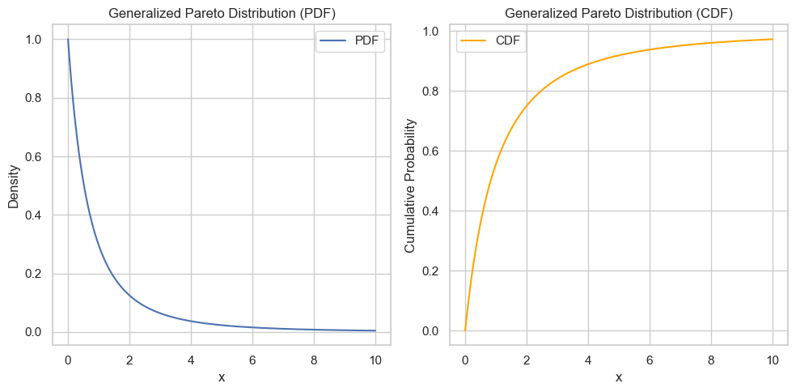

```python
from scipy.stats import genpareto

# Parameters for the Generalized Pareto Distribution
shape_param = 0.5  # ξ (shape parameter)
scale_param = 1.0  # σ (scale parameter)
loc_param = 0.0    # μ (location parameter)

# Generate x values
x = np.linspace(0, 10, 1000)

# PDF and CDF using scipy's genpareto
pdf_values = genpareto.pdf(x, c=shape_param, loc=loc_param, scale=scale_param)
cdf_values = genpareto.cdf(x, c=shape_param, loc=loc_param, scale=scale_param)

# Plotting the PDF
plt.figure(figsize=(10, 5))
plt.subplot(1, 2, 1)
plt.plot(x, pdf_values, label='PDF')
plt.title('Generalized Pareto Distribution (PDF)')
plt.xlabel('x')
plt.ylabel('Density')
plt.grid(True)
plt.legend()

# Plotting the CDF
plt.subplot(1, 2, 2)
plt.plot(x, cdf_values, label='CDF', color='orange')
plt.title('Generalized Pareto Distribution (CDF)')
plt.xlabel('x')
plt.ylabel('Cumulative Probability')
plt.grid(True)
plt.legend()

plt.tight_layout()
plt.show()
```

**Distribution Fitting:**

The functions of the parameters both in GEV and GPD have the same function. Fit the Distribution GEV (Generalized Extreme Value) Distribution:

1. In the block maxima method, you can fit the GEV distribution using Maximum Likelihood Estimation (MLE). The GEV distribution has three parameters -–

   Location ($\mu$): Determines the center of the distribution.

   Scale ($\sigma$): Determines the spread.

   Shape ($\xi$): Governs the tail behavior (whether it is heavy, light, or bounded).
2. GPD (Generalized Pareto Distribution). In the POT approach, fit the GPD to the excesses above the chosen threshold. The GPD distribution also has shape, scale, and threshold parameters. The return level is the value that is expected to be exceeded once on average every T years. This is crucial for risk assessment:

   Return Level: For the GEV distribution, the $T$-year return level $z_T$ is computed by --

$$z_T = \mu + \frac{\sigma}{\xi} \left[ \left( -\ln\left(1 - \frac{1}{T}\right) \right)^{-\xi} - 1 \right]$$

For the GPD distribution, return levels are computed based on the scale and shape parameters for exceedances.

Diagnostics and Model Checking After fitting the model, it’s important to check the fit:

```
Quantile-Quantile (Q-Q) Plots -- Check whether the fitted distribution matches the observed extremes.

Return Level Plot -- Plot return levels against the return periods. This helps validate that your model accurately predicts extreme events for longer return periods.

Residual Analysis -- Analyze residuals to see if they show any patterns (residuals should be randomly distributed).
```

Interpreting the Results:

```
Return Period -- The expected number of years between extreme events of a certain magnitude. For example, the "100-year event" refers to an event that has a 1% chance of occurring in any given year.

Probability of Exceedance -- The likelihood that an extreme event will exceed a given threshold in a particular year.
```

For the following, there's computing the temperature level that is expected to occur, on avaregage, once evey 100 years. The return period $T$ represents the average number of years you would expected between events that exceed a particular extreme value.

The return level, return_level ($T$) function computes the quantile associated with $1 - \frac{1}{T}$ for A GEV distribution:

$$\text{return level} = \text{GEV}_{\mathbf{\dot{}}}\,ppf(1 - \frac{1}{T}\,,\text{shape}\,,\text{location}\,,\text{scale})$$

When $T = 100$ the, this quantile corresponds to $1 - \frac{1}{100}\,=\,0.99$, conveying that there's a 99% probability that this extreme this extreme value will not be reached in any given year; equivalently, a 1% probability it will. By setting $T=100$, there's observation of the $99-$ percentile of extreme values (whether daily, monthly or yearly, depending on the applied block size). This percentile imples a 1% probability of occurence in any given year, being consistent with a 100-year event threshold.

### Statistical Modelling with GEV Distribution Fitting for 100 Year Event

Since this development is working with **at least** a $45-$ year window (about 16,888 days), daily data provides a sufficient sample size.

Developing a Generalised Extreme Value (GEV) distribution analysis for various meteorological variables. Observing the distribution fit is a preliminary step before acquiring future extreme estimates. The GEV model is then applied to predict the magnitude of extreme weather events that occur very rarely (heat extremes, cold extremes, flooding, or wind pressures, etc.).

Here is an analysis of the statistical parameters and what they reveal about the local climate risks. Note that in a 45-year dataset, a 100-year return level is an **extrapolation**—the GEV shape parameter ($\xi$) becomes the most critical factor in determining how "heavy" that unobserved tail is.

**GEV Distribution Fitting (Block Maxima)**

First, to fit the GEV using Maximum Likelihood Estimation (MLE). In scipy, the shape parameter c is defined as $-\xi$.

Why use a "Year" (Annual Block Maxima)?

1. The reason for resampling by Year ('YE') is to satisfy the Asymptotic Justification of Extreme Value Theory.
2. The Fisher-Tippett-Gnedenko Theorem (Fisher and Tippett, 1928; Gnedenko, 1943): This theorem states that if you take the maximum of a "large enough" block of independent observations, those maximums will converge to a Generalized Extreme Value (GEV) distribution.
3. Independence: Daily data is often "auto-correlated" (if it rains hard today, it’s more likely to rain tomorrow). By taking the maximum over a full year, you ensure each data point is independent of the next.
4. Seasonality: Since NYC has distinct seasons (Snow only in winter, Hurricanes mostly in summer/fall), taking a year-long block ensures you capture the "True Extreme" for that cycle, rather than just a seasonal spike.

```python
import pandas as pd
import numpy as np
from scipy.stats import genextreme

# 1. Prepare the dataframe with a DatetimeIndex
df_gev = daily_dataframe.copy()
df_gev.set_index('date', inplace=True)

# 2. Initialize results storage
gev_results = {}
T = 100  # Return Period for the 100-year event

# 3. Loop through numeric variables only
# We exclude non-numeric columns to avoid errors during fitting
numeric_cols = df_gev.select_dtypes(include=[np.number]).columns

for col in numeric_cols:
    # Extract Annual Maxima (Block Maxima)
    # 'YE' stands for Year End; it finds the max value in each calendar year
    annual_max = df_gev[col].resample('YE').max().dropna()

    # Check for sufficient data (need at least a few years to fit a curve)
    if len(annual_max) < 5:
        print(f"Skipping {col}: Only {len(annual_max)} years of data found.")
        continue

    try:
        # Fit GEV distribution using Maximum Likelihood Estimation
        # c is the shape, loc is location (mu), scale is scale (sigma)
        c, loc, scale = genextreme.fit(annual_max)

        # Calculate 100-Year Return Level
        # This is the 99th percentile of the GEV distribution
        return_lvl = genextreme.ppf(1 - 1/T, c, loc, scale)

        # Store results (Converting c to xi where xi = -c)
        gev_results[col] = {
            'Variable': col,
            'Shape_xi': -c,
            'Location_mu': loc,
            'Scale_sigma': scale,
            '100yr_Return_Level': return_lvl
        }
    except Exception as e:
        print(f"Error fitting {col}: {e}")

# 4. Final Results Dataframe for your Fiscal Scenario Matrix
results_df = pd.DataFrame(gev_results).T.reset_index(drop=True)
print(results_df)
```

```
             Variable  Shape_xi  Location_mu Scale_sigma 100yr_Return_Level
0  temperature_2m_max -0.398015    34.215942    2.680538          39.871361
1  temperature_2m_min -0.514581    24.148119    2.587759          28.705541
2            rain_sum   0.07892    48.511685   17.545395         145.820388
3        snowfall_sum  0.026873    11.813044    5.089469          36.733971
4  wind_gusts_10m_max -0.276576    90.913032   11.599368         121.101305
5    pressure_msl_min -0.042452  1033.652562    2.800428        1045.355101
```

**Review of the parameters to interpret the above results:**

We look at how the three core parameters shape the "risk profile" of each variable:

1. Shape ($\xi$): Determines the "tail" of the distribution.

   Negative ($\xi < 0$): The variable has a physical upper limit (e.g., temperature). The distribution is "thin-tailed."

   Positive ($\xi > 0$): The variable is "heavy-tailed," meaning extreme outliers are much more likely (common in rainfall).
2. Location ($\mu$): The "average" extreme value you might see in a typical year.
3. Scale ($\sigma$): The volatility or spread. A higher scale means the gap between a "normal" year and an "extreme" year is wider.
4. 100-Year Return Level: The value expected to be equaled or exceeded once every 100 years (a 1% annual probability).

**Variable Analysis:**

1. Temperature (Max & Min)

   Maximum Temperature: With a $\mu$ of 34.2°C and a negative shape (-0.398), the area experiences consistent heat, but there is a distinct physical "ceiling." The 100-year event reaches 39.9°C, suggesting that while it gets hot, "freak" jumps to 45°C or 50°C are statistically unlikely under current conditions.

   Rainfall: This is the most volatile variable here. The shape is positive (0.079), indicating a "heavy tail." While a typical yearly max rain sum is 48.5mm, the 100-year event jumps to 145.8mm. This high ratio (nearly 3x the location parameter) suggests a high risk of flash flooding or extreme storm events.

   Snowfall: Also shows a positive shape (0.027). The 100-year return level is 36.7 units, which is significantly higher than the typical extreme of 11.8.
3. Wind Gusts & Pressure

   Wind Gusts: The location parameter is 90.9 km/h (or m/s depending on units), with a 100-year peak of 121.1. The negative shape (-0.27) implies that wind speeds are somewhat bounded, likely by the physical geography of the region.

   Pressure: The 100-year level of 1045.3 hPa indicates extreme high-pressure events (anticyclones), which are often associated with very stable, clear, and potentially cold or dry weather depending on the season.

**Key Ideas:**

1. Flood Risk is the Primary Outlier: The positive shape parameter for rain_sum makes it the most "unpredictable" variable. Engineering for drainage should focus on that 145.8mm threshold rather than the average.
2. Thermal Stability: Both max and min temperatures have significant negative shapes. This suggests the climate is stable and predictable; not likely to see temperatures wildly outside the calculated 100-year bounds.
3. Wind Loading: Infrastructure should be rated for at least 121.1 (gusts), as the scale parameter (11.6) shows moderate year-to-year variance in storm intensity.

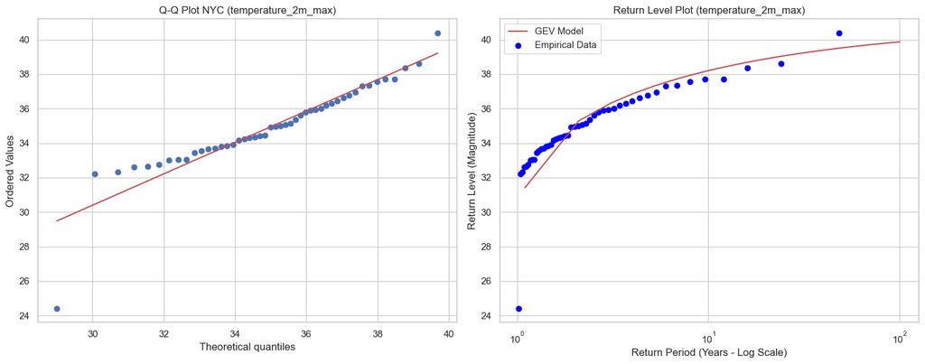

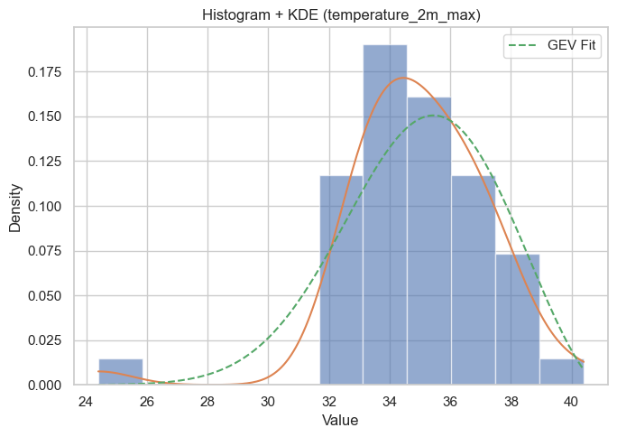

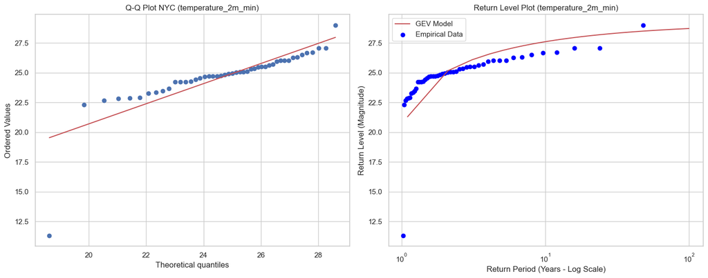

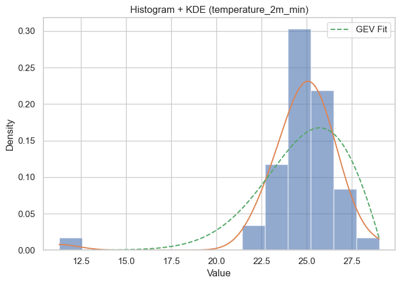

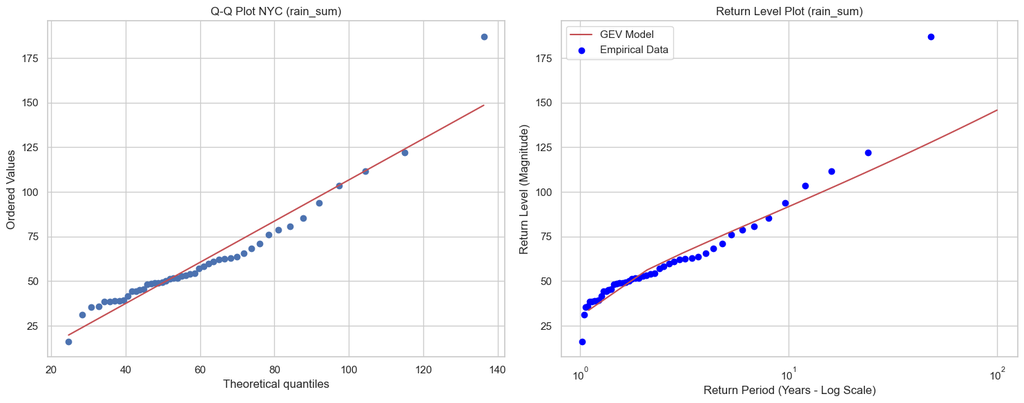

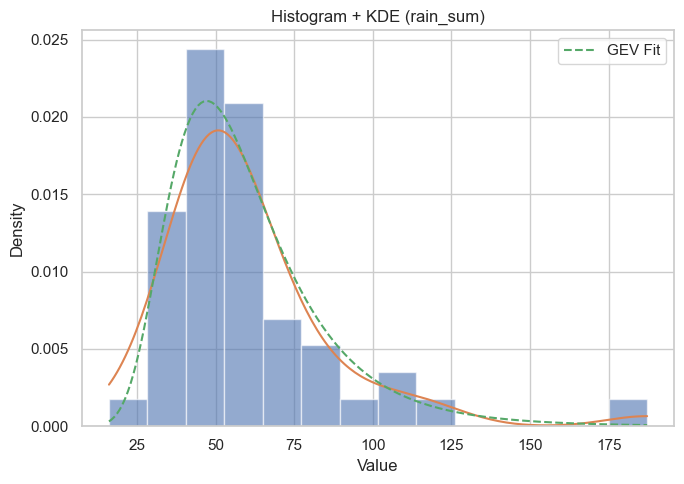

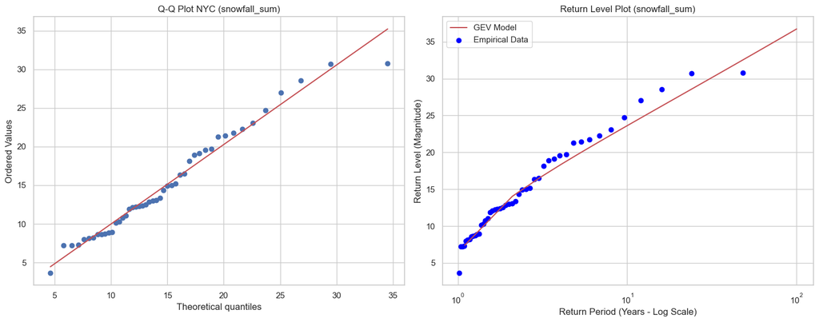

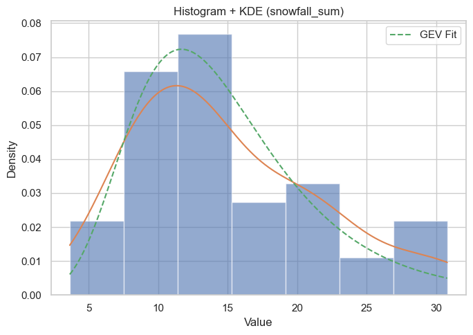

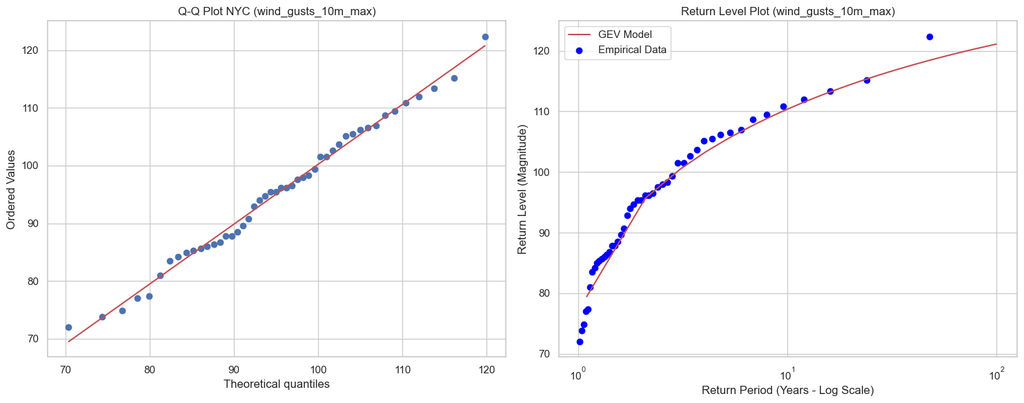

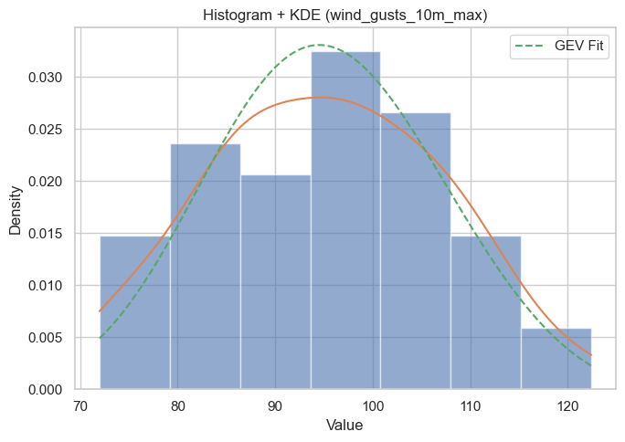

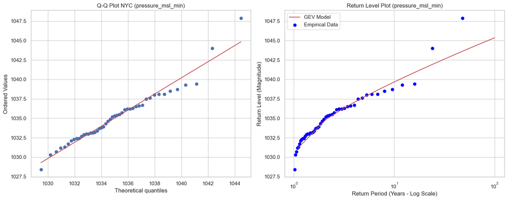

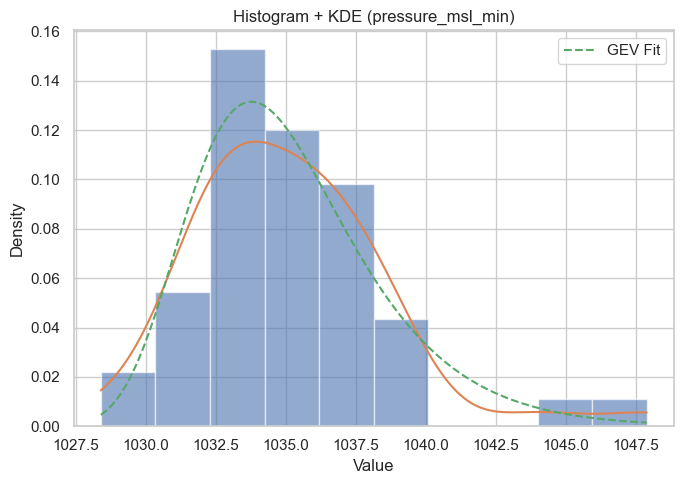

```
             Variable  Shape_xi  Location_mu Scale_sigma 100yr_Return_Level
0  temperature_2m_max -0.398015    34.215942    2.680538          39.871361
1  temperature_2m_min -0.514581    24.148119    2.587759          28.705541
2            rain_sum   0.07892    48.511685   17.545395         145.820388
3        snowfall_sum  0.026873    11.813044    5.089469          36.733971
4  wind_gusts_10m_max -0.276576    90.913032   11.599368         121.101305
5    pressure_msl_min -0.042452  1033.652562    2.800428        1045.355101
```

```python
import matplotlib.pyplot as plt
from scipy import stats

# Optional: store figures if needed
figures = {}

for col in numeric_cols:
    annual_max = df_gev[col].resample('YE').max().dropna()

    if len(annual_max) < 5:
        print(f"Skipping {col}: Only {len(annual_max)} years of data found.")
        continue

    try:
        # Fit GEV
        c, loc, scale = genextreme.fit(annual_max)

        # Return level
        return_lvl = genextreme.ppf(1 - 1/T, c, loc, scale)

        gev_results[col] = {
            'Variable': col,
            'Shape_xi': -c,
            'Location_mu': loc,
            'Scale_sigma': scale,
            '100yr_Return_Level': return_lvl
        }

        # -----------------------------
        # Diagnostic Plots PER VARIABLE
        # -----------------------------
        fig, (ax1, ax2) = plt.subplots(1, 2, figsize=(15, 6))

        # --- Q-Q Plot ---
        stats.probplot(
            annual_max,
            dist=genextreme,
            sparams=(c, loc, scale),
            plot=ax1
        )
        ax1.set_title(f"Q-Q Plot NYC ({col})")

        # --- Return Level Plot ---
        periods = np.linspace(1.1, 100, 100)
        levels = genextreme.ppf(1 - 1/periods, c, loc, scale)

        ax2.semilogx(periods, levels, 'r-', label='GEV Model')

        # Empirical return levels
        sorted_data = np.sort(annual_max)
        n = len(sorted_data)
        empirical_periods = [(n + 1) / (n - i + 1) for i in range(1, n + 1)]

        ax2.scatter(empirical_periods, sorted_data, color='blue', label='Empirical Data')

        ax2.set_xlabel("Return Period (Years - Log Scale)")
        ax2.set_ylabel("Return Level (Magnitude)")
        ax2.set_title(f"Return Level Plot ({col})")
        ax2.legend()

        plt.tight_layout()
        plt.show()

        # Optional: store figure
        figures[col] = fig

        # --- Histogram + KDE Plot ---
        fig, ax = plt.subplots(figsize=(7, 5))

        # Histogram (density normalized)
        ax.hist(annual_max, bins='auto', density=True, alpha=0.6)

        # KDE using scipy
        kde = stats.gaussian_kde(annual_max)
        x_vals = np.linspace(annual_max.min(), annual_max.max(), 200)
        ax.plot(x_vals, kde(x_vals))

        # Optional: overlay fitted GEV PDF
        gev_pdf = genextreme.pdf(x_vals, c, loc, scale)
        ax.plot(x_vals, gev_pdf, linestyle='--', label='GEV Fit')

        ax.set_title(f"Histogram + KDE ({col})")
        ax.set_xlabel("Value")
        ax.set_ylabel("Density")
        ax.legend()

        plt.tight_layout()
        plt.show()

    except Exception as e:
        print(f"Error fitting {col}: {e}")

# Final results
results_df = pd.DataFrame(gev_results).T.reset_index(drop=True)
print(results_df)
```

### Probability of Any of these Variables Exceeding a Specific Threshold (e.g., the chance of rain hitting 100mm in a given year)

Using the Generalized Extreme Value (GEV) parameters you provided, we can calculate the Annual Exceedance Probability (AEP)—the likelihood that a specific value will be met or exceeded in any given year.

**Calculating the Custom Threshold:**

If there's a specific value ($x$) to check, then to apply the GEV formula for exceedance:

$$P(X > x) = 1 - \exp\left( - \left[ 1 + \xi \left( \frac{x - \mu}{\sigma} \right) \right]^{-1/\xi} \right)$$

**Case example, plugging in the "Rain" Numbers:**

Applying the rain variable from the results outpute:

$\mu = 48.511$ (the "centre" of the extreme values)

$\sigma = 17.545$ (the "spread" or volatility)

$\xi = 0.0789$ (the "heaviness" of the tale)

Target $x = 100$ (the threshold you want to check)

Now it's just simple pluggig in values into the above **custom threshold model**, and get the probability output of exceeding the threshold.

Step A: Calculate the normalized deviation

$$\frac{x - \mu}{\sigma} = \frac{100 - 48.511}{17.545} = \mathbf{2.934}$$

Step B: Apply the shape factor

$$1 + \xi(2.934) = 1 + (0.0789 \times 2.934) = \mathbf{1.231}$$

Step C: Raise to the power of $-1/\xi$

$$1.231^{-\frac{1}{0.0789}} = 1.231^{-12.67} \approx \mathbf{0.0713}$$

Step D: Final Exceedance Calculation

$$P = 1 - \exp(-0.0713) \approx 1 - 0.931 = \mathbf{0.069} \text{ (or 6.9\%)}$$

Turning Probability into a "Return Period" - The "1 in N years" figure is simply the inverse of the probability ($1 / P$):

$$\frac{1}{0.069} \approx \mathbf{14.5 \text{ years}}$$

**Calculated Risk Probabilities:**

| Variable | Threshold (x) | Annual Probability (P) | Return Period (1 in N years) |
| --- | --- | --- | --- |
| Temperature Max | $38^{\circ}C$ | $ 11.82\%$ | ~9 years |
| Rain Sum | $100\text{ (mm)}$ | $6.89\%$ | ~14.5 years |
| Wind Gusts | $110\text{ (Km/h)}$ | $10.54\%$ | ~9.5 years |
| Snowfall | $25\text{ (cm)}$ | $7.84\%$ | ~12.7 years |

**Interpreting the above results:**

1. Probability vs. Return Period: The "100-year return level" you provided in your table has an annual probability of exactly $1\%$. The figures above show that events like $100\text{ mm}$ of rain are much more common ($6.89\%$ chance every year), meaning infrastructure is likely to be tested by such an event roughly every $14$ to $15$ years.
2. The "Tail" Effect: Note that even though the Shape ($\xi$) for Rain is positive ($0.079$), the probability of hitting $100\text{ mm}$ is lower than the probability of the Max Temperature hitting $38^{\circ}C$. This is because the "Location" ($\mu$) for rain is much further away from the threshold than it is for temperature. However, because of that positive shape, the "jump" from a $10$-year event to a $100$-year event is much larger for rain than for any other variable.
3. Physical Limits: For Temperature Max ($\xi = -0.398$), there is a theoretical maximum value the model suggests cannot be exceeded (calculated as $\mu - \sigma/\xi$). For your data, this "ceiling" is approximately $40.9^{\circ}C$. This indicates that under the current distribution, a jump to $45^{\circ}C$ is statistically considered "impossible" or outside the current climatic regime.

### Understanding the Acquisition of the $N-$ Year Return Level:**

To understand how the 100-year Return Level ($145.82\text{ mm}$ for rain) arises, the Quantile Function of the GEV distribution is applied. This is essentially the "reverse" of the probability formula exhibited earlier.

Instead of asking "What is the probability of $100\text{ mm}$?", we ask "What value has only a $1\%$ chance of being exceeded?"

**The Math Behind the "100-Year" Value**

The formula for the Return Level ($z_p$) for a given probability ($p$) is:

$$z_p = \mu + \frac{\sigma}{\xi} \left[ \left( -\ln(1-p) \right)^{-\xi} - 1 \right]$$

For a 100-year event, the probability $p$ is $0.01$ (or $1/100$). Plugging in the numbers for THE rain variable row:

$\mu = 48.51$

$\sigma = 17.54$

$\xi = 0.0789$

$p = 0.01$

Step-by-step for Rain:

1. Probability Term: $-\ln(1 - 0.01) = -\ln(0.99) \approx \mathbf{0.01005}$
2. Apply Shape ($\xi$): $(0.01005)^{-0.0789} \approx \mathbf{1.4377}$
3. Scale it: $1.4377 - 1 = 0.4377$. Then multiply by $(\sigma / \xi)$, which is $(17.54 / 0.0789) \approx 222.3$.
4. Final Addition: $48.51 + (222.3 \times 0.4377) = \mathbf{145.82\text{ mm}}$.

**Comparison: 50-Year vs. 100-Year Events**

Based on the model fit of 45 years of data (16888 days), to now also consider the 50-year case (possibly better with the 45 years of weather data. Applying the same math for a 50-year event ($p = 0.02$), here is how the variables compare:

```python
import numpy as np

def gev_return_level(p, mu, sigma, xi):
    # p is the probability of exceedance (e.g., 0.01 for 100-year)
    # G(z_p) = 1 - p
    y_p = -np.log(1 - p)
    if xi != 0:
        return mu + (sigma / xi) * (y_p**(-xi) - 1)
    else:
        # Gumbel case
        return mu - sigma * np.log(y_p)

data = [
    {"Variable": "temperature_2m_max", "xi": -0.398015, "mu": 34.215942, "sigma": 2.680538},
    {"Variable": "temperature_2m_min", "xi": -0.514581, "mu": 24.148119, "sigma": 2.587759},
    {"Variable": "rain_sum", "xi": 0.07892, "mu": 48.511685, "sigma": 17.545395},
    {"Variable": "snowfall_sum", "xi": 0.026873, "mu": 11.813044, "sigma": 5.089469},
    {"Variable": "wind_gusts_10m_max", "xi": -0.276576, "mu": 90.913032, "sigma": 11.599368},
    {"Variable": "pressure_msl_min", "xi": -0.042452, "mu": 1033.652562, "sigma": 2.800428}
]

# Calculate 50-year return levels (p = 0.02)
p_50 = 0.02
p_100 = 0.01

print(f"{'Variable':<20} | {'100-yr Level':<12} | {'50-yr Level':<12}")
print("-" * 50)
for row in data:
    rl_100 = gev_return_level(p_100, row['mu'], row['sigma'], row['xi'])
    rl_50 = gev_return_level(p_50, row['mu'], row['sigma'], row['xi'])
    print(f"{row['Variable']:<20} | {rl_100:<12.4f} | {rl_50:<12.4f}")
```

```
Variable             | 100-yr Level | 50-yr Level
--------------------------------------------------
temperature_2m_max   | 39.8714      | 39.5256
temperature_2m_min   | 28.7055      | 28.5017
rain_sum             | 145.8203     | 128.6844
snowfall_sum         | 36.7340      | 32.7504
wind_gusts_10m_max   | 121.1013     | 118.5982
pressure_msl_min     | 1045.3551    | 1043.7226
```

**Comparison: 50-Year vs. 100-Year Events**

| Variable | 100-Year Level | 50-Year Level | Difference |
| --- | --- | --- | --- |
| Rain Sum | $145.82$ | $128.68$ | $+17.14$ |
| Snowfall Sum | $36.73$ | $32.75$ | $+3.98$ |
| Wind Gusts | $121.10$ | $118.60$ | $+2.50$ |
| Max Temp | $39.87$ | $39.53$ | $+0.34$ |

**Different Gaps Among the Variables**

Obseveice that for Rain, the jump from a 50-year to a 100-year event is huge ($17.14$ units), while for Max Temp, the difference is tiny ($0.34$ units).

This is because of the Shape Parameter ($\xi$):

1. Rain ($\xi = +0.07$): The "positive" shape creates a Fat Tail. Once you cross into extreme territory, the values can escalate rapidly. This is why flood defenses are often built with a much higher safety margin than temperature controls.
2. Temperature ($\xi = -0.39$): The "negative" shape creates a Thin Tail with a physical limit. The distribution "flattens out" as you reach higher values, meaning the 50-year and 100-year extremes are very close to one another.

## Seasonal Analysis of Weather Extremes Based on Quantiles (1975 - 2025)

This new endeavour aims to investigate how weather extremes have evolved over a 50-year period by analysing daily weather observations aggregated into meteorological seasons. Using quantile-based thresholds, the study identifies extreme events—such as unusually high temperatures, heavy rainfall, and strong winds—and evaluates their frequency, intensity, and distribution across Winter, Spring, Summer, and Fall.

The key tasks include defining seasonal structures, constructing extreme event indicators using upper and lower quantiles, and aggregating these events by season and year. Analytical methods focus on detecting long-term trends, shifts in distributions, and changes in the frequency and persistence of extremes. Visualizations such as time series plots, heatmaps, and distribution comparisons are used to highlight seasonal patterns and climate signals.

Overall, this endeavour seeks to provide a clear, data-driven understanding of how seasonal weather extremes have changed over time, offering insights into variability, trends, and potential impacts of climate change.

The data applied is assimilated from Open-Meteo API, centered on NYC for 50 years (1975-2025).

```python
import openmeteo_requests

import pandas as pd
import requests_cache
from retry_requests import retry

# Setup the Open-Meteo API client with cache and retry on error
cache_session = requests_cache.CachedSession('.cache', expire_after = -1)
retry_session = retry(cache_session, retries = 5, backoff_factor = 0.2)
openmeteo = openmeteo_requests.Client(session = retry_session)

# Make sure all required weather variables are listed here
# The order of variables in hourly or daily is important to assign them correctly below
url = "https://archive-api.open-meteo.com/v1/archive"
params = {
	"latitude": 40.7128,
	"longitude": -74.006,
	"start_date": "1975-01-01",
	"end_date": "2025-12-31",
	"daily": ["temperature_2m_max", "temperature_2m_min", "rain_sum", "snowfall_sum", "wind_speed_10m_max", "wind_direction_10m_dominant", "relative_humidity_2m_max", "relative_humidity_2m_min", "pressure_msl_max", "cloud_cover_max", "pressure_msl_min"],
	"timezone": "America/New_York",
}
responses = openmeteo.weather_api(url, params = params)

# Process first location. Add a for-loop for multiple locations or weather models
response = responses[0]
print(f"Coordinates: {response.Latitude()}°N {response.Longitude()}°E")
print(f"Elevation: {response.Elevation()} m asl")
print(f"Timezone: {response.Timezone()}{response.TimezoneAbbreviation()}")
print(f"Timezone difference to GMT+0: {response.UtcOffsetSeconds()}s")

# Process daily data. The order of variables needs to be the same as requested.
daily = response.Daily()
daily_temperature_2m_max = daily.Variables(0).ValuesAsNumpy()
daily_temperature_2m_min = daily.Variables(1).ValuesAsNumpy()
daily_rain_sum = daily.Variables(2).ValuesAsNumpy()
daily_snowfall_sum = daily.Variables(3).ValuesAsNumpy()
daily_wind_speed_10m_max = daily.Variables(4).ValuesAsNumpy()
daily_wind_direction_10m_dominant = daily.Variables(5).ValuesAsNumpy()
daily_relative_humidity_2m_max = daily.Variables(6).ValuesAsNumpy()
daily_relative_humidity_2m_min = daily.Variables(7).ValuesAsNumpy()
daily_pressure_msl_max = daily.Variables(8).ValuesAsNumpy()
daily_cloud_cover_max = daily.Variables(9).ValuesAsNumpy()
daily_pressure_msl_min = daily.Variables(10).ValuesAsNumpy()

daily_data = {"date": pd.date_range(
	start = pd.to_datetime(daily.Time() + response.UtcOffsetSeconds(), unit = "s", utc = True),
	end =  pd.to_datetime(daily.TimeEnd() + response.UtcOffsetSeconds(), unit = "s", utc = True),
	freq = pd.Timedelta(seconds = daily.Interval()),
	inclusive = "left"
)}

daily_data["temperature_2m_max"] = daily_temperature_2m_max
daily_data["temperature_2m_min"] = daily_temperature_2m_min
daily_data["rain_sum"] = daily_rain_sum
daily_data["snowfall_sum"] = daily_snowfall_sum
daily_data["wind_speed_10m_max"] = daily_wind_speed_10m_max
daily_data["wind_direction_10m_dominant"] = daily_wind_direction_10m_dominant
daily_data["relative_humidity_2m_max"] = daily_relative_humidity_2m_max
daily_data["relative_humidity_2m_min"] = daily_relative_humidity_2m_min
daily_data["pressure_msl_max"] = daily_pressure_msl_max
daily_data["cloud_cover_max"] = daily_cloud_cover_max
daily_data["pressure_msl_min"] = daily_pressure_msl_min

daily_weather_data_75_2025 = pd.DataFrame(data = daily_data)
print("\nDaily data\n", daily_weather_data_75_2025)
```

```
Coordinates: 40.738136291503906°N -74.04254150390625°E
Elevation: 32.0 m asl
Timezone: b'America/New_York'b'GMT-4'
Timezone difference to GMT+0: -14400s

Daily data
                            date  temperature_2m_max  temperature_2m_min  \
0     1975-01-01 00:00:00+00:00               7.157               2.007
1     1975-01-02 00:00:00+00:00               3.107              -2.293
2     1975-01-03 00:00:00+00:00               2.557              -2.993
3     1975-01-04 00:00:00+00:00               7.057              -2.043
4     1975-01-05 00:00:00+00:00               4.857              -2.793
...                         ...                 ...                 ...
18623 2025-12-27 00:00:00+00:00              -1.000              -7.300
18624 2025-12-28 00:00:00+00:00               1.050             -11.550
```

[output cut: 57 more lines]

Acquiring a glimpse of the data:

```python
daily_weather_data_75_2025.info()
```

```
<class 'pandas.core.frame.DataFrame'>
RangeIndex: 18628 entries, 0 to 18627
Data columns (total 12 columns):
 #   Column                       Non-Null Count  Dtype
---  ------                       --------------  -----
 0   date                         18628 non-null  datetime64[ns, UTC]
 1   temperature_2m_max           18628 non-null  float32
 2   temperature_2m_min           18628 non-null  float32
 3   rain_sum                     18628 non-null  float32
 4   snowfall_sum                 18628 non-null  float32
 5   wind_speed_10m_max           18628 non-null  float32
 6   wind_direction_10m_dominant  18628 non-null  float32
 7   relative_humidity_2m_max     18628 non-null  float32
 8   relative_humidity_2m_min     18628 non-null  float32
 9   pressure_msl_max             18628 non-null  float32
 10  cloud_cover_max              18628 non-null  float32
 11  pressure_msl_min             18628 non-null  float32
dtypes: datetime64[ns, UTC](1), float32(11)
memory usage: 946.1 KB
```

**Identification of the variables:**

| Variables | Description | Units |
| --- | --- | --- |
| temperature_2m_max | Maximum daily air temperature at 2 meters above ground | $C^{\circ}$ ($F^{\circ}$) |
| temperature_2m_max | Minimum daily air temperature at 2 meters above ground | $C^{\circ}$ ($F^{\circ}$) |
| rain_sum | Sum of daily rain | mm |
| snowfall_sum | Sum of daily snowfall | cm |
| wind_speed_10m_max | Maximum wind speed and gusts on a day | km/h (mph, m/s, knots) |
| wind_direction_10m_dominant | Dominant wind direction | ${\circ}$ |
| relative_humidity_2m_max | Maximum relative humidity measured at 2 meters above ground for the day | % |
| relative_humidity_2m_min | Minimum relative humidity measured at 2 meters above ground for the day | % |
| pressure_msl_max | Maximum atmospheric air pressure reduced to mean sea level (msl) or pressure at surface | hPa |
| pressure_msl_min | Minimum atmospheric air pressure reduced to mean sea level (msl) or pressure at surface | hPa |
| cloud_cover_max | Maximum cloud coverage observed | % |

Checking for missing values:

```python
daily_weather_data_75_2025.isnull().sum()
```

```
date                           0
temperature_2m_max             0
temperature_2m_min             0
rain_sum                       0
snowfall_sum                   0
wind_speed_10m_max             0
wind_direction_10m_dominant    0
relative_humidity_2m_max       0
relative_humidity_2m_min       0
pressure_msl_max               0
cloud_cover_max                0
pressure_msl_min               0
dtype: int64
```

**Meteorological Season Definition (NYC)**

Meteorological seasons are fixed 3-month blocks commonly used in climatology to ensure consistency in seasonal comparisons (NOAA NCEI, n.d.):

Winter: December (12), January (1), February (2)

Spring: March (3), April (4), May (5)

Summer: June (6), July (7), August (8)

Fall (Autumn): September (9), October (10), November (11)

Seasonal periods will be identified by the months. Will extract both month and year attributes out of the datetime format to label seasons and for the ability to develop time series.

```python
# Meteorological seasons definition

seasons_df = daily_weather_data_75_2025.copy()

seasons_df['year'] = seasons_df['date'].dt.year
seasons_df['month'] = seasons_df['date'].dt.month
seasons_df['month'] = seasons_df['date'].dt.month

def get_meteorological_season(month):
    if month in [12, 1, 2]:
        return 'Winter'
    elif month in [3, 4, 5]:
        return 'Spring'
    elif month in [6, 7, 8]:
        return 'Summer'
    else:
        return 'Fall'

seasons_df['season'] = seasons_df['month'].apply(get_meteorological_season)

seasons_df.info()
```

```
<class 'pandas.core.frame.DataFrame'>
RangeIndex: 18628 entries, 0 to 18627
Data columns (total 15 columns):
 #   Column                       Non-Null Count  Dtype
---  ------                       --------------  -----
 0   date                         18628 non-null  datetime64[ns, UTC]
 1   temperature_2m_max           18628 non-null  float32
 2   temperature_2m_min           18628 non-null  float32
 3   rain_sum                     18628 non-null  float32
 4   snowfall_sum                 18628 non-null  float32
 5   wind_speed_10m_max           18628 non-null  float32
 6   wind_direction_10m_dominant  18628 non-null  float32
 7   relative_humidity_2m_max     18628 non-null  float32
 8   relative_humidity_2m_min     18628 non-null  float32
 9   pressure_msl_max             18628 non-null  float32
 10  cloud_cover_max              18628 non-null  float32
 11  pressure_msl_min             18628 non-null  float32
 12  year                         18628 non-null  int32
 13  month                        18628 non-null  int32
 14  season                       18628 non-null  object
dtypes: datetime64[ns, UTC](1), float32(11), int32(2), object(1)
memory usage: 1.2+ MB
```

### Box-and-Whisker Plots

Box plots (or box-and-whisker plots) serve to visualize the distribution of numerical data by displaying its key statistics: minimum, first quartile (Q1), median (Q2), third quartile (Q3), and maximum. They are primarily used to identify outliers, detect data symmetry, measure spread (variability), and compare distributions across multiple categories.

Key Purposes and Uses:

1. Summarize Distribution: Provides a compact visual summary of a data set, showing center (median), spread (interquartile range), and skewness.
2. Identify Outliers: Effectively highlights data points that fall outside the expected range of whiskers (extreme values).
3. Compare Data Sets: Facilitates side-by-side comparison of multiple data sets or categories to identify differences in medians or variability.
4. Show Variability: Helps determine how tightly clustered or dispersed data points are around the median.

Components of a Box Plot:

1. Median (Q2): The line inside the box representing the midpoint of data.
2. Interquartile Range (IQR): The box itself, representing the middle 50% of the data $(Q3 - Q1)$.
3. Whiskers: Lines extending to the minimum and maximum data values (excluding outliers), showing the range of data.
4. Outliers: Individual points beyond the whiskers.

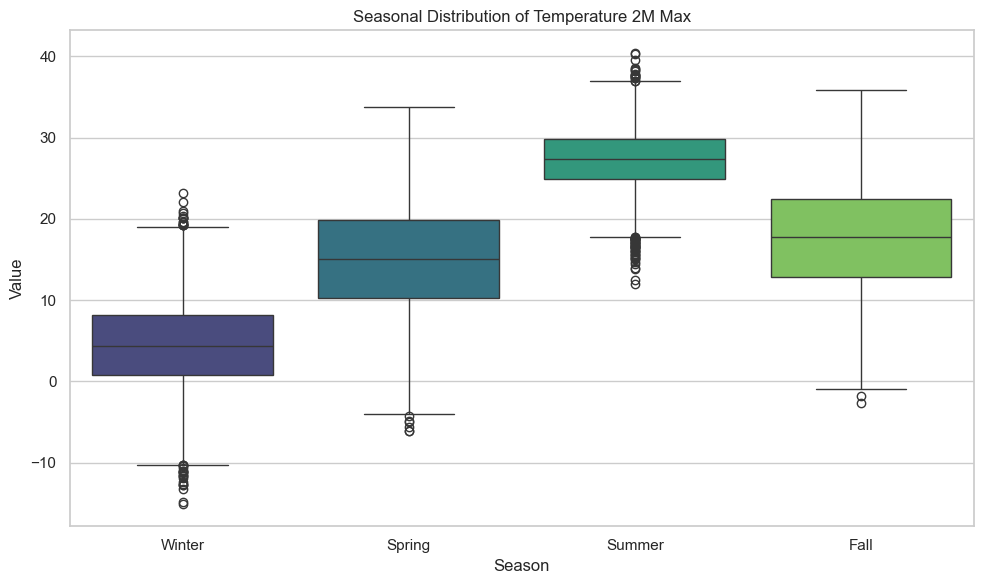

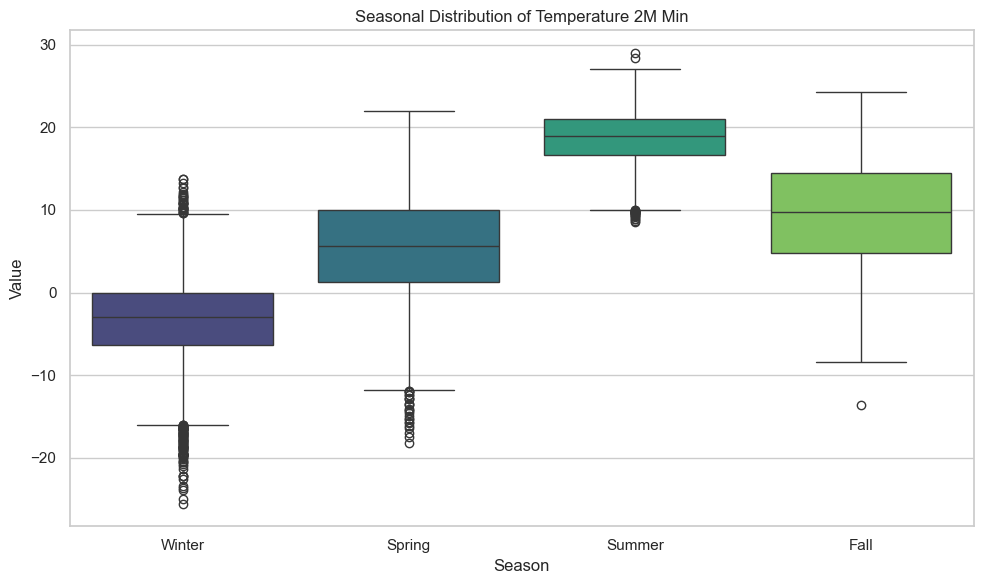

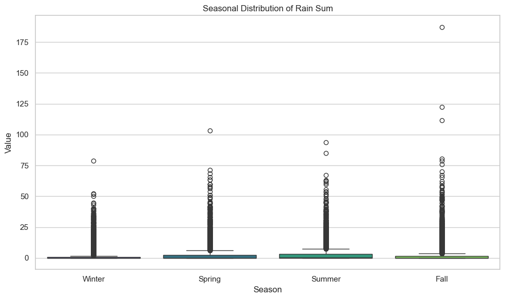

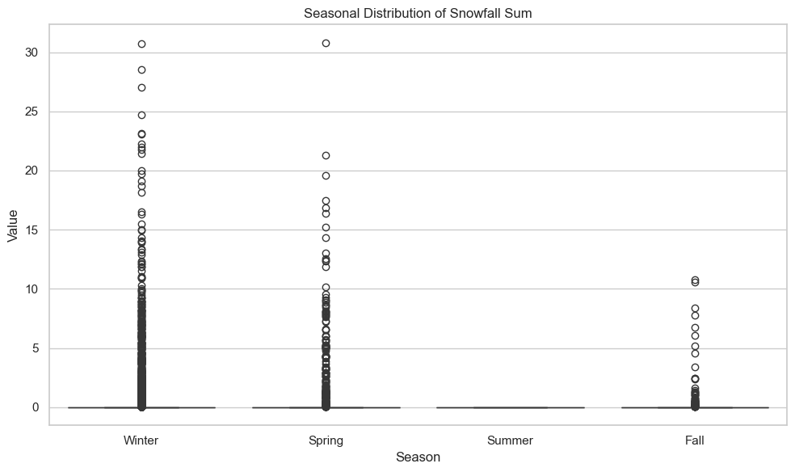

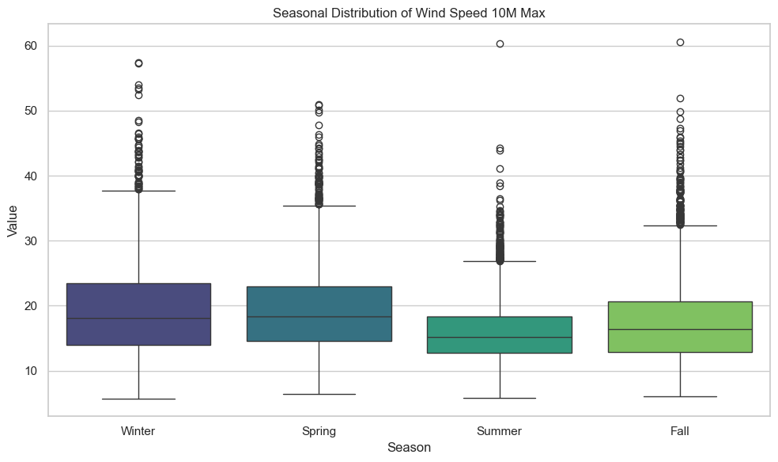

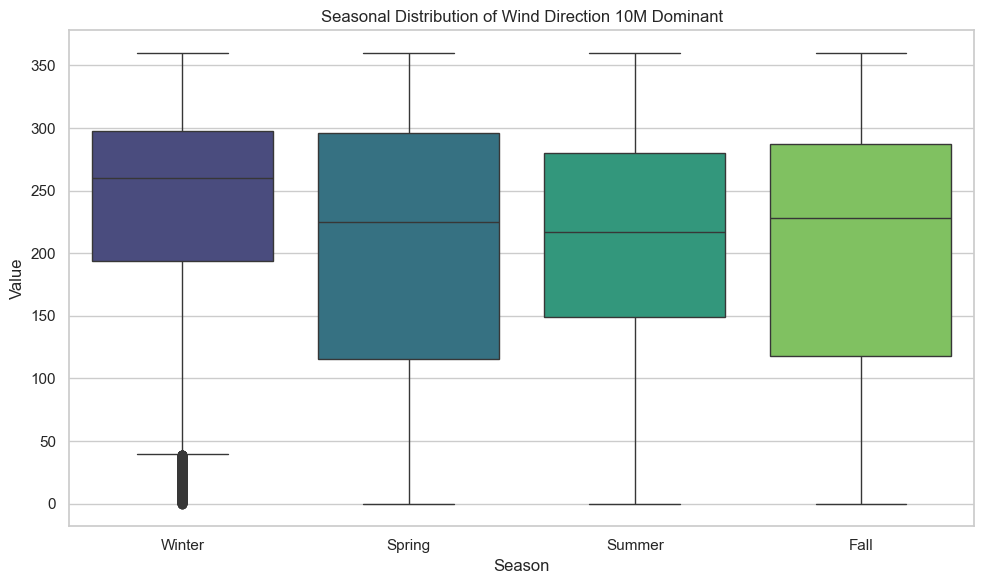

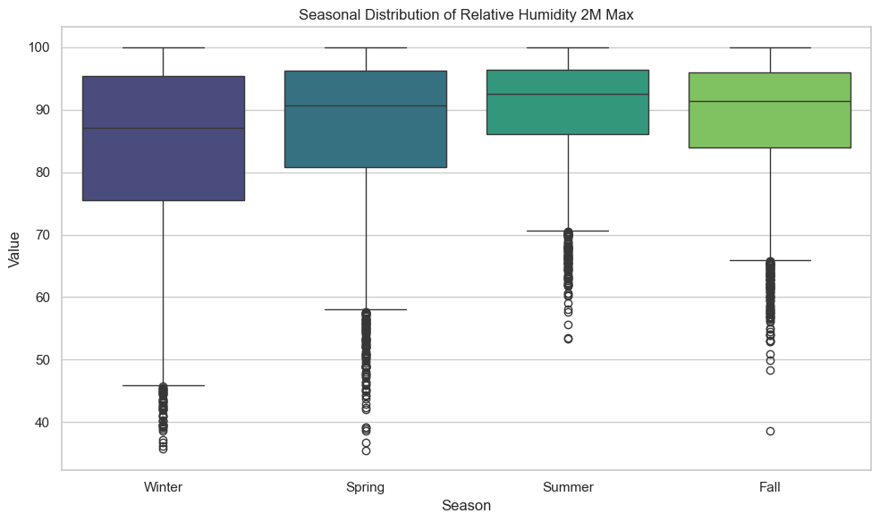

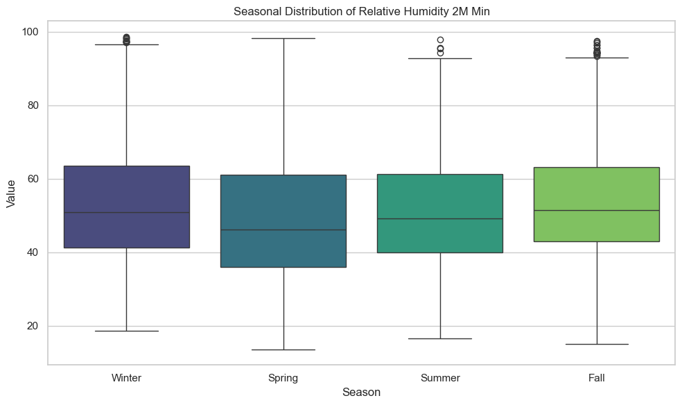

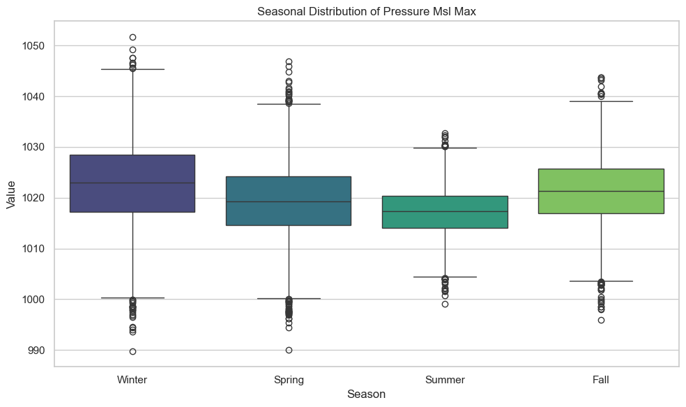

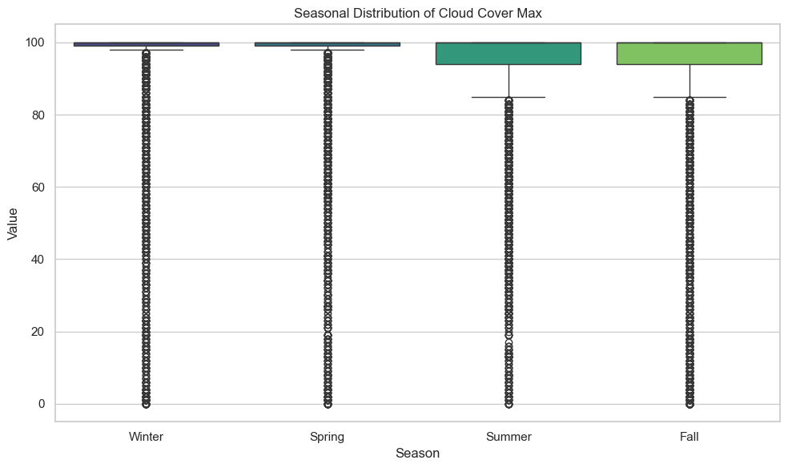

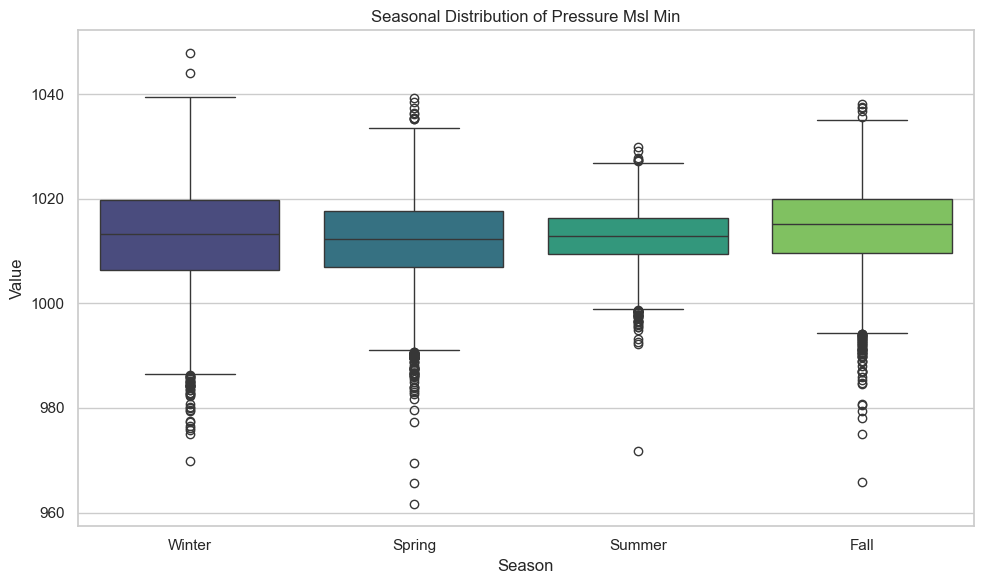

```python
import matplotlib.pyplot as plt
import seaborn as sns

# 1. Define the columns to exclude
exclude_cols = ['date', 'year', 'month', 'season']

# 2. Filter for numerical columns
numerical_cols = [col for col in seasons_df.columns if col not in exclude_cols]

# 3. Iterate and Plot with the fix
for col in numerical_cols:
    plt.figure(figsize=(10, 6))

    pretty_title = col.replace('_', ' ').title()

    # FIX: Assign x to hue and set legend=False to stop the warning
    sns.boxplot(
        data=seasons_df,
        x='season',
        y=col,
        hue='season', # aasigning the 'x' variable to 'hue'and setting `legend=False` for the same effect.
        palette='viridis',
        legend=False
    )

    plt.title(f'Seasonal Distribution of {pretty_title}')
    plt.ylabel('Value')
    plt.xlabel('Season')

    plt.tight_layout()
    plt.show()
```

### Defining Extremes via Quantiles

Systematic interuptions stemming from weather activity generally concerns measures or events that exceed a particular threshold for disruptions to occur within a specified time frame. Transportation and infrastructure both have limits in function with respect to weather activity. Accumulation or magnitude type dynamics in weather are generally physical or spatial in nature. Hence, disruptions or hindrances in the ambiance are inevitable.

In weather analysis, using quantiles, **specifically the 95th and 5th percentiles**, is a decent way to define "extreme" events relative to a specific location's typical climate. Instead of using a fixed number (like "35°C is hot"), to apply the data to tell you what "hot" means for that specific area.

**Fixed Threshold Issues --** Thresholds for extremes are not fixed. A contrary stance yeilds the following issues:

1. Non-stationarity, or the realistic setting

   ```
     Climate / seasonal effects → wind distributions shift over time

     A fixed 60 Km/h may:

           be too low in storm seasons (too many exceedances)

           too high in calm periods (too few exceedances)
   ```

2. Bias in tail estimation consequence from 1

   ```
     Too many points: violates asymptotic GPD assumption

     Too few: unstable/unreliable parameter estimates
   ```

3. Not transferable

   ```
   Different locations / variables have different scales. A fixed value is generally not a model. An example, different units and scales for speed: m/s, Km/h, mph, knots, etc. There's similar issue for precipitation accumulation.
   ```

**Quantile-Based Threshold (Static) --** Attributes of quantile-based thresholds:

1. Always uses top 5% extremes
2. Ensures enough data for fitting regardless of the nature of respectivr season.
3. Standard in EVT literature

**Rolling Threshold (Adaptive) --** When practical:

1. Strong seasonality (e.g., hurricanes vs dry season). In a temperate climate (which NYC resides in) temperature and preciptation behaviours often overlap, say, winter $\rightarrow$ spring $\rightarrow$ summer $\rightarrow$ autumn $\rightarrow$ winter. In tropical climates, hurricane seasons are significant from calm periods, and dry seasons are significant from wet seasons; ecological activity, agricultural activity and property damage are strong evidence.
2. Non-stationary climate trends. Non-stationary climate trends refer to shifts in climate data—such as temperature and rainfall—where statistical properties like mean, variance, and frequency change over time, rendering traditional historical averages obsolete. Driven by climate change, this phenomenon makes extreme events harder to predict and necessitates new modeling techniques for environmental planning. Time-varying parameters and moving window analysis, are necessary for accurately assessing climate risks or climate regimes.
3. High-frequency data (hourly wind, rainfall). Rolling schemes act like a "filter" or "smoother" for moisy hourly or electromagnetic sensing data.

To identify unusual or "extreme" observations for a respective month throughout each year for the entire 50 year span. Creating extreme indicator attributes:

```python
# Define a dictionary of columns and their respective quantile directions
# (1 = high is extreme, 0 = low is extreme)
config = {
    'temperature_2m_max': (0.95, 'extreme_heat'),
    'temperature_2m_min': (0.05, 'extreme_cold'),
    'rain_sum': (0.95, 'extreme_rain'),
    'wind_speed_10m_max': (0.95, 'extreme_wind'),
    'wind_direction_10m_dominant': (0.95, 'extreme_wind_direction'),
    'snowfall_sum': (0.95, 'extreme_snow'),
    'relative_humidity_2m_max': (0.95, 'extreme_high_humidity'),
    'relative_humidity_2m_min': (0.05, 'extreme_low_humidity'),
    'pressure_msl_max': (0.95, 'extreme_high_press_msl'),
    'pressure_msl_min': (0.05, 'extreme_low_press_msl'),
    'cloud_cover_max': (0.95, 'extreme_cloud_cov')
}

# Apply the seasonal logic
for col, (q, name) in config.items():
    # Calculate threshold per month
    thresholds = seasons_df.groupby('month')[col].transform(lambda x: x.quantile(q))

    # Compare based on direction
    if q > 0.5:
        seasons_df[name] = seasons_df[col] >= thresholds
    else:
        seasons_df[name] = seasons_df[col] <= thresholds
```

```python
seasons_df['extreme_heat'].describe()
```

```
count     18628
unique        2
top       False
freq      17679
Name: extreme_heat, dtype: object
```

Checking out the new data type for the extreme attrabutes in the dataframe:

```python
seasons_df.info() # True or False
```

```
<class 'pandas.core.frame.DataFrame'>
RangeIndex: 18628 entries, 0 to 18627
Data columns (total 26 columns):
 #   Column                       Non-Null Count  Dtype
---  ------                       --------------  -----
 0   date                         18628 non-null  datetime64[ns, UTC]
 1   temperature_2m_max           18628 non-null  float32
 2   temperature_2m_min           18628 non-null  float32
 3   rain_sum                     18628 non-null  float32
 4   snowfall_sum                 18628 non-null  float32
 5   wind_speed_10m_max           18628 non-null  float32
 6   wind_direction_10m_dominant  18628 non-null  float32
 7   relative_humidity_2m_max     18628 non-null  float32
 8   relative_humidity_2m_min     18628 non-null  float32
 9   pressure_msl_max             18628 non-null  float32
```

[output cut: 18 more lines]

**Aggregating Extremes**

After already deciding what counts as "extreme", now to no longer look at the specific instances of a meteorological measure; focus will be looking for the checkmarks.

```
Analogy: It’s like a teacher stoping to look at every grade and instead just counting how many times a student got an "A" or an "F."
```

In addition, to place the data into buckets based on the Year and the Season (Spring, Summer, Fall, Winter).

Adding up the extreme cases. Say, if in some season the extreme type has count is $X$, recognised is $X$ different cases that the season in question was hit by extreme type. This turns a messy list of thousands of instances into a simple table that tells you exactly where the "danger" is.

In essence, taking "noisy" data and turns it into a "High-Level Map" that allows for the observation for which seasons are the riskiest and how that risk is changing over time.

```python
seasonal_extremes = (
    seasons_df.groupby(['year', 'season'])
    .agg({
        # Counts of Extreme Events
        'extreme_heat': 'sum',
        'extreme_cold': 'sum',
        'extreme_rain': 'sum',
        'extreme_wind': 'sum',
        'extreme_snow': 'sum',
        'extreme_high_humidity': 'sum',
        'extreme_low_humidity': 'sum',
        'extreme_wind_direction': 'sum',
        'extreme_high_press_msl': 'sum',
        'extreme_low_press_msl': 'sum',
        'extreme_cloud_cov': 'sum',
    })
    .reset_index()
)
```

### Seasonal Extreme Event Trends (Visual Perspective)

Purpose: Show long-term climate signal

   For example, imagine your "Extreme Heat" data for a single year is a jagged mountain peak. One year is record-breakingly hot, the next is unusually cool. This "noise" makes it hard to see if the world is actually warming.

```python
import matplotlib.pyplot as plt
import seaborn as sns

sns.set_theme(style="whitegrid", context="talk")

extreme_cols = [
    'extreme_heat', 'extreme_cold', 'extreme_rain', 'extreme_wind',
    'extreme_snow', 'extreme_high_humidity', 'extreme_low_humidity',
    'extreme_wind_direction', 'extreme_high_press_msl',
    'extreme_low_press_msl', 'extreme_cloud_cov'
]

# Optional: cleaner titles
pretty_names = {col: col.replace('_', ' ').title() for col in extreme_cols}
```

Seasonal Aggregation (generic):

```python
seasonal_extremes_all = (
    seasonal_extremes.groupby(['year', 'season'])[extreme_cols]
    .sum()
    .reset_index()
)
```